# Risk Factor Analysis

## Outcome Variable

**Outcome Variable:** wast_rec90d

## Predictor Variables

**Intervention Variable:** impsan

**Adjustment Set:**

unadjusted

## Stratifying Variables

The analysis was stratified on these variable(s):

- agecat
- studyid
- country

## Data Summary

| agecat | studyid | country | impsan | wast_rec90d | n_cell | n | outcome_variable |
| --- | --- | --- | --- | --- | --- | --- | --- |
| 0-24 months | ki0047075b-MAL-ED | BANGLADESH | 1 | 0 | 33 | 121 | wast_rec90d |
| 0-24 months | ki0047075b-MAL-ED | BANGLADESH | 1 | 1 | 67 | 121 | wast_rec90d |
| 0-24 months | ki0047075b-MAL-ED | BANGLADESH | 0 | 0 | 10 | 121 | wast_rec90d |
| 0-24 months | ki0047075b-MAL-ED | BANGLADESH | 0 | 1 | 11 | 121 | wast_rec90d |
| 0-24 months | ki0047075b-MAL-ED | BRAZIL | 1 | 0 | 6 | 24 | wast_rec90d |
| 0-24 months | ki0047075b-MAL-ED | BRAZIL | 1 | 1 | 17 | 24 | wast_rec90d |
| 0-24 months | ki0047075b-MAL-ED | BRAZIL | 0 | 0 | 0 | 24 | wast_rec90d |
| 0-24 months | ki0047075b-MAL-ED | BRAZIL | 0 | 1 | 1 | 24 | wast_rec90d |
| 0-24 months | ki0047075b-MAL-ED | INDIA | 1 | 0 | 25 | 172 | wast_rec90d |
| 0-24 months | ki0047075b-MAL-ED | INDIA | 1 | 1 | 43 | 172 | wast_rec90d |
| 0-24 months | ki0047075b-MAL-ED | INDIA | 0 | 0 | 39 | 172 | wast_rec90d |
| 0-24 months | ki0047075b-MAL-ED | INDIA | 0 | 1 | 65 | 172 | wast_rec90d |
| 0-24 months | ki0047075b-MAL-ED | NEPAL | 1 | 0 | 19 | 97 | wast_rec90d |
| 0-24 months | ki0047075b-MAL-ED | NEPAL | 1 | 1 | 78 | 97 | wast_rec90d |
| 0-24 months | ki0047075b-MAL-ED | NEPAL | 0 | 0 | 0 | 97 | wast_rec90d |
| 0-24 months | ki0047075b-MAL-ED | NEPAL | 0 | 1 | 0 | 97 | wast_rec90d |
| 0-24 months | ki0047075b-MAL-ED | PERU | 1 | 0 | 3 | 33 | wast_rec90d |
| 0-24 months | ki0047075b-MAL-ED | PERU | 1 | 1 | 6 | 33 | wast_rec90d |
| 0-24 months | ki0047075b-MAL-ED | PERU | 0 | 0 | 3 | 33 | wast_rec90d |
| 0-24 months | ki0047075b-MAL-ED | PERU | 0 | 1 | 21 | 33 | wast_rec90d |
| 0-24 months | ki0047075b-MAL-ED | SOUTH AFRICA | 1 | 0 | 1 | 79 | wast_rec90d |
| 0-24 months | ki0047075b-MAL-ED | SOUTH AFRICA | 1 | 1 | 1 | 79 | wast_rec90d |
| 0-24 months | ki0047075b-MAL-ED | SOUTH AFRICA | 0 | 0 | 12 | 79 | wast_rec90d |
| 0-24 months | ki0047075b-MAL-ED | SOUTH AFRICA | 0 | 1 | 65 | 79 | wast_rec90d |
| 0-24 months | ki0047075b-MAL-ED | TANZANIA, UNITED REPUBLIC OF | 1 | 0 | 0 | 50 | wast_rec90d |
| 0-24 months | ki0047075b-MAL-ED | TANZANIA, UNITED REPUBLIC OF | 1 | 1 | 0 | 50 | wast_rec90d |
| 0-24 months | ki0047075b-MAL-ED | TANZANIA, UNITED REPUBLIC OF | 0 | 0 | 9 | 50 | wast_rec90d |
| 0-24 months | ki0047075b-MAL-ED | TANZANIA, UNITED REPUBLIC OF | 0 | 1 | 41 | 50 | wast_rec90d |
| 0-24 months | ki1017093-NIH-Birth | BANGLADESH | 1 | 0 | 66 | 421 | wast_rec90d |
| 0-24 months | ki1017093-NIH-Birth | BANGLADESH | 1 | 1 | 81 | 421 | wast_rec90d |

[output cut: 174 more lines]

The following strata were considered:

- agecat: 0-24 months, studyid: ki0047075b-MAL-ED, country: BANGLADESH
- agecat: 0-24 months, studyid: ki0047075b-MAL-ED, country: BRAZIL
- agecat: 0-24 months, studyid: ki0047075b-MAL-ED, country: INDIA
- agecat: 0-24 months, studyid: ki0047075b-MAL-ED, country: NEPAL
- agecat: 0-24 months, studyid: ki0047075b-MAL-ED, country: PERU
- agecat: 0-24 months, studyid: ki0047075b-MAL-ED, country: SOUTH AFRICA
- agecat: 0-24 months, studyid: ki0047075b-MAL-ED, country: TANZANIA, UNITED REPUBLIC OF
- agecat: 0-24 months, studyid: ki1017093-NIH-Birth, country: BANGLADESH
- agecat: 0-24 months, studyid: ki1017093b-PROVIDE, country: BANGLADESH
- agecat: 0-24 months, studyid: ki1017093c-NIH-Crypto, country: BANGLADESH
- agecat: 0-24 months, studyid: ki1114097-CONTENT, country: PERU
- agecat: 0-24 months, studyid: ki1135781-COHORTS, country: GUATEMALA
- agecat: 0-24 months, studyid: ki1135781-COHORTS, country: INDIA
- agecat: 0-24 months, studyid: ki1135781-COHORTS, country: PHILIPPINES
- agecat: 0-24 months, studyid: ki1148112-LCNI-5, country: MALAWI
- agecat: 0-24 months, studyid: kiGH5241-JiVitA-3, country: BANGLADESH
- agecat: 0-24 months, studyid: kiGH5241-JiVitA-4, country: BANGLADESH
- agecat: 0-6 months, studyid: ki0047075b-MAL-ED, country: BANGLADESH
- agecat: 0-6 months, studyid: ki0047075b-MAL-ED, country: BRAZIL
- agecat: 0-6 months, studyid: ki0047075b-MAL-ED, country: INDIA
- agecat: 0-6 months, studyid: ki0047075b-MAL-ED, country: NEPAL
- agecat: 0-6 months, studyid: ki0047075b-MAL-ED, country: PERU
- agecat: 0-6 months, studyid: ki0047075b-MAL-ED, country: SOUTH AFRICA
- agecat: 0-6 months, studyid: ki0047075b-MAL-ED, country: TANZANIA, UNITED REPUBLIC OF
- agecat: 0-6 months, studyid: ki1017093-NIH-Birth, country: BANGLADESH
- agecat: 0-6 months, studyid: ki1017093b-PROVIDE, country: BANGLADESH
- agecat: 0-6 months, studyid: ki1017093c-NIH-Crypto, country: BANGLADESH
- agecat: 0-6 months, studyid: ki1114097-CONTENT, country: PERU
- agecat: 0-6 months, studyid: ki1135781-COHORTS, country: GUATEMALA
- agecat: 0-6 months, studyid: ki1135781-COHORTS, country: INDIA
- agecat: 0-6 months, studyid: ki1135781-COHORTS, country: PHILIPPINES
- agecat: 0-6 months, studyid: ki1148112-LCNI-5, country: MALAWI
- agecat: 0-6 months, studyid: kiGH5241-JiVitA-3, country: BANGLADESH
- agecat: 0-6 months, studyid: kiGH5241-JiVitA-4, country: BANGLADESH
- agecat: 6-24 months, studyid: ki0047075b-MAL-ED, country: BANGLADESH
- agecat: 6-24 months, studyid: ki0047075b-MAL-ED, country: BRAZIL
- agecat: 6-24 months, studyid: ki0047075b-MAL-ED, country: INDIA
- agecat: 6-24 months, studyid: ki0047075b-MAL-ED, country: NEPAL
- agecat: 6-24 months, studyid: ki0047075b-MAL-ED, country: PERU
- agecat: 6-24 months, studyid: ki0047075b-MAL-ED, country: SOUTH AFRICA
- agecat: 6-24 months, studyid: ki0047075b-MAL-ED, country: TANZANIA, UNITED REPUBLIC OF
- agecat: 6-24 months, studyid: ki1017093-NIH-Birth, country: BANGLADESH
- agecat: 6-24 months, studyid: ki1017093b-PROVIDE, country: BANGLADESH
- agecat: 6-24 months, studyid: ki1017093c-NIH-Crypto, country: BANGLADESH
- agecat: 6-24 months, studyid: ki1114097-CONTENT, country: PERU
- agecat: 6-24 months, studyid: ki1135781-COHORTS, country: GUATEMALA
- agecat: 6-24 months, studyid: ki1135781-COHORTS, country: INDIA
- agecat: 6-24 months, studyid: ki1135781-COHORTS, country: PHILIPPINES
- agecat: 6-24 months, studyid: ki1148112-LCNI-5, country: MALAWI
- agecat: 6-24 months, studyid: kiGH5241-JiVitA-3, country: BANGLADESH
- agecat: 6-24 months, studyid: kiGH5241-JiVitA-4, country: BANGLADESH

### Dropped Strata

Some strata were dropped due to rare outcomes:

- agecat: 0-24 months, studyid: ki0047075b-MAL-ED, country: BRAZIL
- agecat: 0-24 months, studyid: ki0047075b-MAL-ED, country: NEPAL
- agecat: 0-24 months, studyid: ki0047075b-MAL-ED, country: PERU
- agecat: 0-24 months, studyid: ki0047075b-MAL-ED, country: SOUTH AFRICA
- agecat: 0-24 months, studyid: ki0047075b-MAL-ED, country: TANZANIA, UNITED REPUBLIC OF
- agecat: 0-24 months, studyid: ki1017093b-PROVIDE, country: BANGLADESH
- agecat: 0-24 months, studyid: ki1114097-CONTENT, country: PERU
- agecat: 0-24 months, studyid: ki1148112-LCNI-5, country: MALAWI
- agecat: 0-6 months, studyid: ki0047075b-MAL-ED, country: BANGLADESH
- agecat: 0-6 months, studyid: ki0047075b-MAL-ED, country: BRAZIL
- agecat: 0-6 months, studyid: ki0047075b-MAL-ED, country: NEPAL
- agecat: 0-6 months, studyid: ki0047075b-MAL-ED, country: PERU
- agecat: 0-6 months, studyid: ki0047075b-MAL-ED, country: SOUTH AFRICA
- agecat: 0-6 months, studyid: ki0047075b-MAL-ED, country: TANZANIA, UNITED REPUBLIC OF
- agecat: 0-6 months, studyid: ki1017093b-PROVIDE, country: BANGLADESH
- agecat: 0-6 months, studyid: ki1017093c-NIH-Crypto, country: BANGLADESH
- agecat: 0-6 months, studyid: ki1114097-CONTENT, country: PERU
- agecat: 0-6 months, studyid: ki1135781-COHORTS, country: GUATEMALA
- agecat: 0-6 months, studyid: ki1148112-LCNI-5, country: MALAWI
- agecat: 6-24 months, studyid: ki0047075b-MAL-ED, country: BANGLADESH
- agecat: 6-24 months, studyid: ki0047075b-MAL-ED, country: BRAZIL
- agecat: 6-24 months, studyid: ki0047075b-MAL-ED, country: NEPAL
- agecat: 6-24 months, studyid: ki0047075b-MAL-ED, country: PERU
- agecat: 6-24 months, studyid: ki0047075b-MAL-ED, country: SOUTH AFRICA
- agecat: 6-24 months, studyid: ki0047075b-MAL-ED, country: TANZANIA, UNITED REPUBLIC OF
- agecat: 6-24 months, studyid: ki1017093b-PROVIDE, country: BANGLADESH
- agecat: 6-24 months, studyid: ki1017093c-NIH-Crypto, country: BANGLADESH
- agecat: 6-24 months, studyid: ki1114097-CONTENT, country: PERU
- agecat: 6-24 months, studyid: ki1135781-COHORTS, country: GUATEMALA
- agecat: 6-24 months, studyid: ki1135781-COHORTS, country: INDIA
- agecat: 6-24 months, studyid: ki1148112-LCNI-5, country: MALAWI
- agecat: 6-24 months, studyid: kiGH5241-JiVitA-3, country: BANGLADESH

## Methods Detail

We’re interested in the causal parameters $E[Y_a]$ for all values of $a \in \mathcal{A}$. These parameters represent the mean outcome if, possibly contrary to fact, we intervened to set all units to have $A=a$. Under the randomization and positivity assumptions, these are identified by the statistical parameters $\psi_a=E_W[E_{Y|A,W}(Y|A=a,W)]$. In addition, we’re interested in the mean of $Y$, $E[Y]$ under no intervention (the observed mean). We will estimate these parameters by using SuperLearner to fit the relevant likelihood factors – $E_{Y|A,W}(Y|A=a,W)$ and $p(A=a|W)$, and then updating our likelihood fit using a joint TMLE.

For unadjusted analyses ($W=\{\}$), initial likelihoods were estimated using Lrnr_glm to estimate the simple $E(Y|A)$ and Lrnr_mean to estimate $p(A)$. For adjusted analyses, a small library containing Lrnr_glmnet, Lrnr_xgboost, and Lrnr_mean was used.

Having estimated these parameters, we will then use the delta method to estimate relative risks and attributable risks relative to a prespecified baseline level of $A$.

# Results Detail

## Results Plots

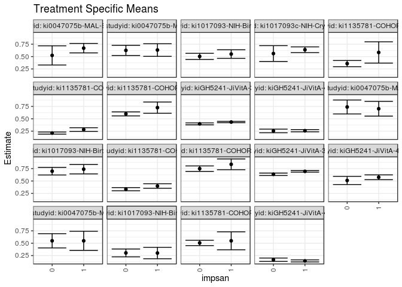

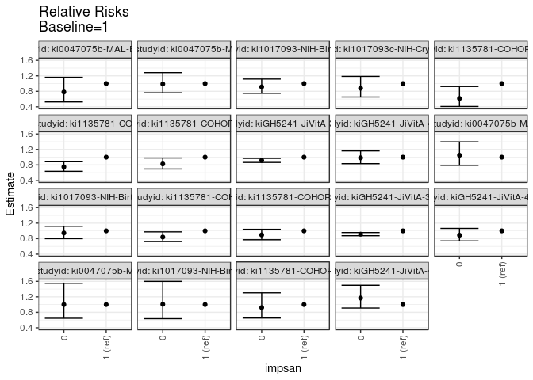

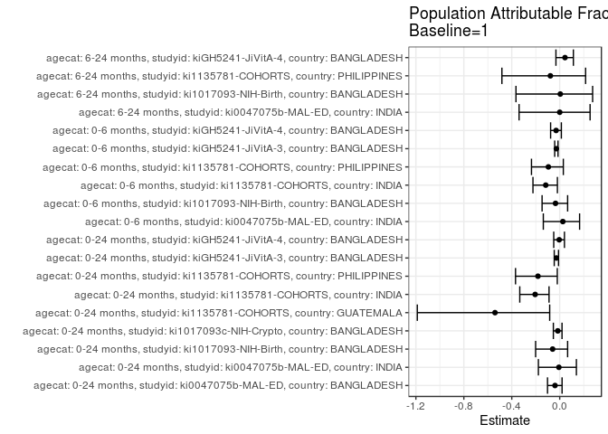

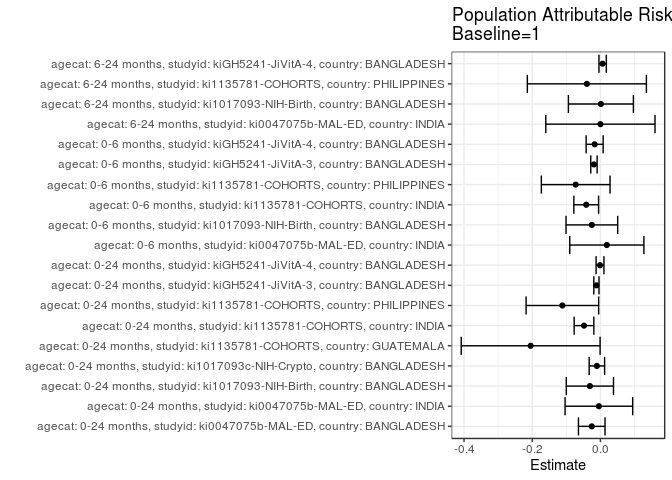

## Results Table

### Parameter: TSM

| agecat | studyid | country | intervention_level | baseline_level | estimate | ci_lower | ci_upper |
| --- | --- | --- | --- | --- | --- | --- | --- |
| 0-24 months | ki0047075b-MAL-ED | BANGLADESH | 1 | NA | 0.6700000 | 0.5744320 | 0.7655680 |
| 0-24 months | ki0047075b-MAL-ED | BANGLADESH | 0 | NA | 0.5238095 | 0.3303014 | 0.7173177 |
| 0-24 months | ki0047075b-MAL-ED | INDIA | 1 | NA | 0.6323529 | 0.5048556 | 0.7598503 |
| 0-24 months | ki0047075b-MAL-ED | INDIA | 0 | NA | 0.6250000 | 0.5219164 | 0.7280836 |
| 0-24 months | ki1017093-NIH-Birth | BANGLADESH | 1 | NA | 0.5510204 | 0.4645738 | 0.6374670 |
| 0-24 months | ki1017093-NIH-Birth | BANGLADESH | 0 | NA | 0.5036496 | 0.4414527 | 0.5658466 |
| 0-24 months | ki1017093c-NIH-Crypto | BANGLADESH | 1 | NA | 0.6377358 | 0.5802574 | 0.6952143 |
| 0-24 months | ki1017093c-NIH-Crypto | BANGLADESH | 0 | NA | 0.5609756 | 0.4014318 | 0.7205194 |
| 0-24 months | ki1135781-COHORTS | GUATEMALA | 1 | NA | 0.5833333 | 0.3683989 | 0.7982678 |
| 0-24 months | ki1135781-COHORTS | GUATEMALA | 0 | NA | 0.3583333 | 0.2956074 | 0.4210592 |
| 0-24 months | ki1135781-COHORTS | INDIA | 1 | NA | 0.2825397 | 0.2459315 | 0.3191479 |
| 0-24 months | ki1135781-COHORTS | INDIA | 0 | NA | 0.2117117 | 0.1902035 | 0.2332199 |
| 0-24 months | ki1135781-COHORTS | PHILIPPINES | 1 | NA | 0.7250000 | 0.6113567 | 0.8386433 |
| 0-24 months | ki1135781-COHORTS | PHILIPPINES | 0 | NA | 0.5986733 | 0.5582519 | 0.6390947 |
| 0-24 months | kiGH5241-JiVitA-3 | BANGLADESH | 1 | NA | 0.4342233 | 0.4205828 | 0.4478639 |
| 0-24 months | kiGH5241-JiVitA-3 | BANGLADESH | 0 | NA | 0.3976945 | 0.3785167 | 0.4168724 |
| 0-24 months | kiGH5241-JiVitA-4 | BANGLADESH | 1 | NA | 0.2591362 | 0.2362124 | 0.2820601 |
| 0-24 months | kiGH5241-JiVitA-4 | BANGLADESH | 0 | NA | 0.2549372 | 0.2189585 | 0.2909158 |
| 0-6 months | ki0047075b-MAL-ED | INDIA | 1 | NA | 0.7027027 | 0.5539789 | 0.8514265 |
| 0-6 months | ki0047075b-MAL-ED | INDIA | 0 | NA | 0.7380952 | 0.5976960 | 0.8784945 |
| 0-6 months | ki1017093-NIH-Birth | BANGLADESH | 1 | NA | 0.7380952 | 0.6434348 | 0.8327557 |
| 0-6 months | ki1017093-NIH-Birth | BANGLADESH | 0 | NA | 0.6978417 | 0.6216977 | 0.7739857 |
| 0-6 months | ki1135781-COHORTS | INDIA | 1 | NA | 0.3982103 | 0.3528118 | 0.4436088 |
| 0-6 months | ki1135781-COHORTS | INDIA | 0 | NA | 0.3345196 | 0.3026570 | 0.3663822 |
| 0-6 months | ki1135781-COHORTS | PHILIPPINES | 1 | NA | 0.8367347 | 0.7280039 | 0.9454655 |
| 0-6 months | ki1135781-COHORTS | PHILIPPINES | 0 | NA | 0.7489177 | 0.6935154 | 0.8043201 |
| 0-6 months | kiGH5241-JiVitA-3 | BANGLADESH | 1 | NA | 0.6945137 | 0.6785787 | 0.7104488 |
| 0-6 months | kiGH5241-JiVitA-3 | BANGLADESH | 0 | NA | 0.6355263 | 0.6113185 | 0.6597341 |
| 0-6 months | kiGH5241-JiVitA-4 | BANGLADESH | 1 | NA | 0.5753086 | 0.5271245 | 0.6234928 |
| 0-6 months | kiGH5241-JiVitA-4 | BANGLADESH | 0 | NA | 0.5104895 | 0.4284825 | 0.5924965 |
| 6-24 months | ki0047075b-MAL-ED | INDIA | 1 | NA | 0.5483871 | 0.3554241 | 0.7413501 |
| 6-24 months | ki0047075b-MAL-ED | INDIA | 0 | NA | 0.5483871 | 0.4046587 | 0.6921155 |
| 6-24 months | ki1017093-NIH-Birth | BANGLADESH | 1 | NA | 0.3015873 | 0.1861854 | 0.4169892 |
| 6-24 months | ki1017093-NIH-Birth | BANGLADESH | 0 | NA | 0.3037037 | 0.2246718 | 0.3827357 |
| 6-24 months | ki1135781-COHORTS | PHILIPPINES | 1 | NA | 0.5483871 | 0.3670161 | 0.7297581 |
| 6-24 months | ki1135781-COHORTS | PHILIPPINES | 0 | NA | 0.5053763 | 0.4516690 | 0.5590836 |
| 6-24 months | kiGH5241-JiVitA-4 | BANGLADESH | 1 | NA | 0.1427273 | 0.1220970 | 0.1633575 |
| 6-24 months | kiGH5241-JiVitA-4 | BANGLADESH | 0 | NA | 0.1666667 | 0.1328485 | 0.2004848 |

### Parameter: E(Y)

| agecat | studyid | country | intervention_level | baseline_level | estimate | ci_lower | ci_upper |
| --- | --- | --- | --- | --- | --- | --- | --- |
| 0-24 months | ki0047075b-MAL-ED | BANGLADESH | NA | NA | 0.6446281 | 0.5577732 | 0.7314830 |
| 0-24 months | ki0047075b-MAL-ED | INDIA | NA | NA | 0.6279070 | 0.5477344 | 0.7080796 |
| 0-24 months | ki1017093-NIH-Birth | BANGLADESH | NA | NA | 0.5201900 | 0.4695846 | 0.5707955 |
| 0-24 months | ki1017093c-NIH-Crypto | BANGLADESH | NA | NA | 0.6274510 | 0.5732906 | 0.6816113 |
| 0-24 months | ki1135781-COHORTS | GUATEMALA | NA | NA | 0.3787879 | 0.3179432 | 0.4396325 |
| 0-24 months | ki1135781-COHORTS | INDIA | NA | NA | 0.2344546 | 0.2156201 | 0.2532892 |
| 0-24 months | ki1135781-COHORTS | PHILIPPINES | NA | NA | 0.6134700 | 0.5751620 | 0.6517779 |
| 0-24 months | kiGH5241-JiVitA-3 | BANGLADESH | NA | NA | 0.4224868 | 0.4113573 | 0.4336163 |
| 0-24 months | kiGH5241-JiVitA-4 | BANGLADESH | NA | NA | 0.2580019 | 0.2386523 | 0.2773515 |
| 0-6 months | ki0047075b-MAL-ED | INDIA | NA | NA | 0.7215190 | 0.6193314 | 0.8237066 |
| 0-6 months | ki1017093-NIH-Birth | BANGLADESH | NA | NA | 0.7130045 | 0.6535890 | 0.7724200 |
| 0-6 months | ki1135781-COHORTS | INDIA | NA | NA | 0.3565891 | 0.3304405 | 0.3827378 |
| 0-6 months | ki1135781-COHORTS | PHILIPPINES | NA | NA | 0.7642857 | 0.7146210 | 0.8139505 |
| 0-6 months | kiGH5241-JiVitA-3 | BANGLADESH | NA | NA | 0.6755499 | 0.6622049 | 0.6888949 |
| 0-6 months | kiGH5241-JiVitA-4 | BANGLADESH | NA | NA | 0.5583942 | 0.5167799 | 0.6000084 |
| 6-24 months | ki0047075b-MAL-ED | INDIA | NA | NA | 0.5483871 | 0.4327976 | 0.6639766 |
| 6-24 months | ki1017093-NIH-Birth | BANGLADESH | NA | NA | 0.3030303 | 0.2377927 | 0.3682679 |
| 6-24 months | ki1135781-COHORTS | PHILIPPINES | NA | NA | 0.5086849 | 0.4571562 | 0.5602135 |
| 6-24 months | kiGH5241-JiVitA-4 | BANGLADESH | NA | NA | 0.1492734 | 0.1316631 | 0.1668838 |

### Parameter: RR

| agecat | studyid | country | intervention_level | baseline_level | estimate | ci_lower | ci_upper |
| --- | --- | --- | --- | --- | --- | --- | --- |
| 0-24 months | ki0047075b-MAL-ED | BANGLADESH | 1 | 1 | 1.0000000 | 1.0000000 | 1.0000000 |
| 0-24 months | ki0047075b-MAL-ED | BANGLADESH | 0 | 1 | 0.7818053 | 0.5261486 | 1.1616859 |
| 0-24 months | ki0047075b-MAL-ED | INDIA | 1 | 1 | 1.0000000 | 1.0000000 | 1.0000000 |
| 0-24 months | ki0047075b-MAL-ED | INDIA | 0 | 1 | 0.9883721 | 0.7617151 | 1.2824735 |
| 0-24 months | ki1017093-NIH-Birth | BANGLADESH | 1 | 1 | 1.0000000 | 1.0000000 | 1.0000000 |
| 0-24 months | ki1017093-NIH-Birth | BANGLADESH | 0 | 1 | 0.9140308 | 0.7485355 | 1.1161159 |
| 0-24 months | ki1017093c-NIH-Crypto | BANGLADESH | 1 | 1 | 1.0000000 | 1.0000000 | 1.0000000 |
| 0-24 months | ki1017093c-NIH-Crypto | BANGLADESH | 0 | 1 | 0.8796363 | 0.6525074 | 1.1858258 |
| 0-24 months | ki1135781-COHORTS | GUATEMALA | 1 | 1 | 1.0000000 | 1.0000000 | 1.0000000 |
| 0-24 months | ki1135781-COHORTS | GUATEMALA | 0 | 1 | 0.6142857 | 0.4085128 | 0.9237090 |
| 0-24 months | ki1135781-COHORTS | INDIA | 1 | 1 | 1.0000000 | 1.0000000 | 1.0000000 |
| 0-24 months | ki1135781-COHORTS | INDIA | 0 | 1 | 0.7493167 | 0.6355719 | 0.8834179 |
| 0-24 months | ki1135781-COHORTS | PHILIPPINES | 1 | 1 | 1.0000000 | 1.0000000 | 1.0000000 |
| 0-24 months | ki1135781-COHORTS | PHILIPPINES | 0 | 1 | 0.8257563 | 0.6961780 | 0.9794528 |
| 0-24 months | kiGH5241-JiVitA-3 | BANGLADESH | 1 | 1 | 1.0000000 | 1.0000000 | 1.0000000 |
| 0-24 months | kiGH5241-JiVitA-3 | BANGLADESH | 0 | 1 | 0.9158755 | 0.8646529 | 0.9701326 |
| 0-24 months | kiGH5241-JiVitA-4 | BANGLADESH | 1 | 1 | 1.0000000 | 1.0000000 | 1.0000000 |
| 0-24 months | kiGH5241-JiVitA-4 | BANGLADESH | 0 | 1 | 0.9837960 | 0.8328454 | 1.1621059 |
| 0-6 months | ki0047075b-MAL-ED | INDIA | 1 | 1 | 1.0000000 | 1.0000000 | 1.0000000 |
| 0-6 months | ki0047075b-MAL-ED | INDIA | 0 | 1 | 1.0503663 | 0.7902143 | 1.3961647 |
| 0-6 months | ki1017093-NIH-Birth | BANGLADESH | 1 | 1 | 1.0000000 | 1.0000000 | 1.0000000 |
| 0-6 months | ki1017093-NIH-Birth | BANGLADESH | 0 | 1 | 0.9454630 | 0.7989425 | 1.1188542 |
| 0-6 months | ki1135781-COHORTS | INDIA | 1 | 1 | 1.0000000 | 1.0000000 | 1.0000000 |
| 0-6 months | ki1135781-COHORTS | INDIA | 0 | 1 | 0.8400576 | 0.7240869 | 0.9746022 |
| 0-6 months | ki1135781-COHORTS | PHILIPPINES | 1 | 1 | 1.0000000 | 1.0000000 | 1.0000000 |
| 0-6 months | ki1135781-COHORTS | PHILIPPINES | 0 | 1 | 0.8950480 | 0.7707387 | 1.0394068 |
| 0-6 months | kiGH5241-JiVitA-3 | BANGLADESH | 1 | 1 | 1.0000000 | 1.0000000 | 1.0000000 |
| 0-6 months | kiGH5241-JiVitA-3 | BANGLADESH | 0 | 1 | 0.9150666 | 0.8752673 | 0.9566756 |
| 0-6 months | kiGH5241-JiVitA-4 | BANGLADESH | 1 | 1 | 1.0000000 | 1.0000000 | 1.0000000 |
| 0-6 months | kiGH5241-JiVitA-4 | BANGLADESH | 0 | 1 | 0.8873316 | 0.7402979 | 1.0635682 |
| 6-24 months | ki0047075b-MAL-ED | INDIA | 1 | 1 | 1.0000000 | 1.0000000 | 1.0000000 |
| 6-24 months | ki0047075b-MAL-ED | INDIA | 0 | 1 | 1.0000000 | 0.6453048 | 1.5496552 |
| 6-24 months | ki1017093-NIH-Birth | BANGLADESH | 1 | 1 | 1.0000000 | 1.0000000 | 1.0000000 |
| 6-24 months | ki1017093-NIH-Birth | BANGLADESH | 0 | 1 | 1.0070175 | 0.6341484 | 1.5991277 |
| 6-24 months | ki1135781-COHORTS | PHILIPPINES | 1 | 1 | 1.0000000 | 1.0000000 | 1.0000000 |
| 6-24 months | ki1135781-COHORTS | PHILIPPINES | 0 | 1 | 0.9215686 | 0.6511208 | 1.3043489 |
| 6-24 months | kiGH5241-JiVitA-4 | BANGLADESH | 1 | 1 | 1.0000000 | 1.0000000 | 1.0000000 |
| 6-24 months | kiGH5241-JiVitA-4 | BANGLADESH | 0 | 1 | 1.1677282 | 0.9101777 | 1.4981571 |

### Parameter: PAR

| agecat | studyid | country | intervention_level | baseline_level | estimate | ci_lower | ci_upper |
| --- | --- | --- | --- | --- | --- | --- | --- |
| 0-24 months | ki0047075b-MAL-ED | BANGLADESH | 1 | NA | -0.0253719 | -0.0643372 | 0.0135934 |
| 0-24 months | ki0047075b-MAL-ED | INDIA | 1 | NA | -0.0044460 | -0.1035757 | 0.0946838 |
| 0-24 months | ki1017093-NIH-Birth | BANGLADESH | 1 | NA | -0.0308304 | -0.1000663 | 0.0384055 |
| 0-24 months | ki1017093c-NIH-Crypto | BANGLADESH | 1 | NA | -0.0102849 | -0.0328916 | 0.0123219 |
| 0-24 months | ki1135781-COHORTS | GUATEMALA | 1 | NA | -0.2045455 | -0.4081981 | -0.0008928 |
| 0-24 months | ki1135781-COHORTS | INDIA | 1 | NA | -0.0480850 | -0.0769423 | -0.0192278 |
| 0-24 months | ki1135781-COHORTS | PHILIPPINES | 1 | NA | -0.1115300 | -0.2179199 | -0.0051402 |
| 0-24 months | kiGH5241-JiVitA-3 | BANGLADESH | 1 | NA | -0.0117366 | -0.0193116 | -0.0041615 |
| 0-24 months | kiGH5241-JiVitA-4 | BANGLADESH | 1 | NA | -0.0011343 | -0.0126617 | 0.0103931 |
| 0-6 months | ki0047075b-MAL-ED | INDIA | 1 | NA | 0.0188163 | -0.0899213 | 0.1275539 |
| 0-6 months | ki1017093-NIH-Birth | BANGLADESH | 1 | NA | -0.0250908 | -0.1008550 | 0.0506735 |
| 0-6 months | ki1135781-COHORTS | INDIA | 1 | NA | -0.0416211 | -0.0779039 | -0.0053384 |
| 0-6 months | ki1135781-COHORTS | PHILIPPINES | 1 | NA | -0.0724490 | -0.1732018 | 0.0283039 |
| 0-6 months | kiGH5241-JiVitA-3 | BANGLADESH | 1 | NA | -0.0189638 | -0.0283141 | -0.0096135 |
| 0-6 months | kiGH5241-JiVitA-4 | BANGLADESH | 1 | NA | -0.0169145 | -0.0418490 | 0.0080200 |
| 6-24 months | ki0047075b-MAL-ED | INDIA | 1 | NA | 0.0000000 | -0.1601409 | 0.1601409 |
| 6-24 months | ki1017093-NIH-Birth | BANGLADESH | 1 | NA | 0.0014430 | -0.0938618 | 0.0967478 |
| 6-24 months | ki1135781-COHORTS | PHILIPPINES | 1 | NA | -0.0397022 | -0.2142926 | 0.1348881 |
| 6-24 months | kiGH5241-JiVitA-4 | BANGLADESH | 1 | NA | 0.0065462 | -0.0042800 | 0.0173724 |

### Parameter: PAF

| agecat | studyid | country | intervention_level | baseline_level | estimate | ci_lower | ci_upper |
| --- | --- | --- | --- | --- | --- | --- | --- |
| 0-24 months | ki0047075b-MAL-ED | BANGLADESH | 1 | NA | -0.0393590 | -0.1017847 | 0.0195298 |
| 0-24 months | ki0047075b-MAL-ED | INDIA | 1 | NA | -0.0070806 | -0.1780040 | 0.1390425 |
| 0-24 months | ki1017093-NIH-Birth | BANGLADESH | 1 | NA | -0.0592675 | -0.2011193 | 0.0658315 |
| 0-24 months | ki1017093c-NIH-Crypto | BANGLADESH | 1 | NA | -0.0163915 | -0.0531800 | 0.0191120 |
| 0-24 months | ki1135781-COHORTS | GUATEMALA | 1 | NA | -0.5400000 | -1.1882863 | -0.0837704 |
| 0-24 months | ki1135781-COHORTS | INDIA | 1 | NA | -0.2050932 | -0.3333330 | -0.0891874 |
| 0-24 months | ki1135781-COHORTS | PHILIPPINES | 1 | NA | -0.1818019 | -0.3688183 | -0.0203368 |
| 0-24 months | kiGH5241-JiVitA-3 | BANGLADESH | 1 | NA | -0.0277797 | -0.0458606 | -0.0100115 |
| 0-24 months | kiGH5241-JiVitA-4 | BANGLADESH | 1 | NA | -0.0043964 | -0.0500718 | 0.0392922 |
| 0-6 months | ki0047075b-MAL-ED | INDIA | 1 | NA | 0.0260787 | -0.1369378 | 0.1657216 |
| 0-6 months | ki1017093-NIH-Birth | BANGLADESH | 1 | NA | -0.0351902 | -0.1472525 | 0.0659260 |
| 0-6 months | ki1135781-COHORTS | INDIA | 1 | NA | -0.1167202 | -0.2233429 | -0.0193903 |
| 0-6 months | ki1135781-COHORTS | PHILIPPINES | 1 | NA | -0.0947931 | -0.2355973 | 0.0299657 |
| 0-6 months | kiGH5241-JiVitA-3 | BANGLADESH | 1 | NA | -0.0280716 | -0.0420436 | -0.0142870 |
| 0-6 months | kiGH5241-JiVitA-4 | BANGLADESH | 1 | NA | -0.0302913 | -0.0760227 | 0.0134965 |
| 6-24 months | ki0047075b-MAL-ED | INDIA | 1 | NA | 0.0000000 | -0.3391320 | 0.2532476 |
| 6-24 months | ki1017093-NIH-Birth | BANGLADESH | 1 | NA | 0.0047619 | -0.3651133 | 0.2744200 |
| 6-24 months | ki1135781-COHORTS | PHILIPPINES | 1 | NA | -0.0780488 | -0.4824650 | 0.2160428 |
| 6-24 months | kiGH5241-JiVitA-4 | BANGLADESH | 1 | NA | 0.0438536 | -0.0316676 | 0.1138464 |